# **Problem Statement**

## Business Context

A sales forecast is a prediction of future sales revenue based on historical data, industry trends, and the status of the current sales pipeline. Businesses use the sales forecast to estimate weekly, monthly, quarterly, and annual sales totals. A company needs to make an accurate sales forecast as it adds value across an organization and helps the different verticals to chalk out their future course of action.

Forecasting helps an organization plan its sales operations by region and provides valuable insights to the supply chain team regarding the procurement of goods and materials. An accurate sales forecast process has many benefits which include improved decision-making about the future and reduction of sales pipeline and forecast risks. Moreover, it helps to reduce the time spent in planning territory coverage and establish benchmarks that can be used to assess trends in the future.

## Objective

SuperKart is a retail chain operating supermarkets and food marts across various tier cities, offering a wide range of products. To optimize its inventory management and make informed decisions around regional sales strategies, SuperKart wants to accurately forecast the sales revenue of its outlets for the upcoming quarter.

To operationalize these insights at scale, the company has partnered with a data science firm—not just to build a predictive model based on historical sales data, but to develop and deploy a robust forecasting solution that can be integrated into SuperKart’s decision-making systems and used across its network of stores.

## Data Description

The data contains the different attributes of the various products and stores.The detailed data dictionary is given below.

- **Product_Id** - unique identifier of each product, each identifier having two letters at the beginning followed by a number.
- **Product_Weight** - weight of each product
- **Product_Sugar_Content** - sugar content of each product like low sugar, regular and no sugar
- **Product_Allocated_Area** - ratio of the allocated display area of each product to the total display area of all the products in a store
- **Product_Type** - broad category for each product like meat, snack foods, hard drinks, dairy, canned, soft drinks, health and hygiene, baking goods, bread, breakfast, frozen foods, fruits and vegetables, household, seafood, starchy foods, others
- **Product_MRP** - maximum retail price of each product
- **Store_Id** - unique identifier of each store
- **Store_Establishment_Year** - year in which the store was established
- **Store_Size** - size of the store depending on sq. feet like high, medium and low
- **Store_Location_City_Type** - type of city in which the store is located like Tier 1, Tier 2 and Tier 3. Tier 1 consists of cities where the standard of living is comparatively higher than its Tier 2 and Tier 3 counterparts.
- **Store_Type** - type of store depending on the products that are being sold there like Departmental Store, Supermarket Type 1, Supermarket Type 2 and Food Mart
- **Product_Store_Sales_Total** - total revenue generated by the sale of that particular product in that particular store

# **Installing and Importing the necessary libraries**

```python
#Installing the libraries with the specified versions
!pip install numpy==2.0.2 pandas==2.2.2 scikit-learn==1.6.1 matplotlib==3.10.0 seaborn==0.13.2 joblib==1.4.2 xgboost==2.1.4 requests==2.32.4 huggingface_hub==0.34.0 -q
```

[output not shown]

**Note:**

- After running the above cell, kindly restart the notebook kernel (for Jupyter Notebook) or runtime (for Google Colab) and run all cells sequentially from the next cell.
- On executing the above line of code, you might see a warning regarding package dependencies. This error message can be ignored as the above code ensures that all necessary libraries and their dependencies are maintained to successfully execute the code in this notebook.

```python
import warnings
warnings.filterwarnings("ignore")

# Libraries to help with reading and manipulating data
import numpy as np
import pandas as pd

# Libaries to help with data visualization
import matplotlib.pyplot as plt
import seaborn as sns

# Removes the limit for the number of displayed columns
pd.set_option("display.max_columns", None)
# Sets the limit for the number of displayed rows
pd.set_option("display.max_rows", 100)

import statsmodels.api as sm
import statsmodels.stats.api as sms

from statsmodels.stats.outliers_influence import variance_inflation_factor
from scipy import stats

# for data preprocessing and pipeline creation
from sklearn.model_selection import train_test_split
from sklearn.impute import SimpleImputer
from sklearn.preprocessing import StandardScaler, OneHotEncoder
from sklearn.compose import make_column_transformer
from sklearn.pipeline import make_pipeline
from sklearn import metrics
from sklearn.pipeline import Pipeline # Import Pipeline

# Libraries different ensemble classifiers
from sklearn.ensemble import (
    BaggingRegressor,
    RandomForestRegressor,
    AdaBoostRegressor,
    GradientBoostingRegressor,
)
from xgboost import XGBRegressor
from sklearn.tree import DecisionTreeRegressor

# Libraries to get different metric scores
from sklearn.metrics import (
    confusion_matrix,
    accuracy_score,
    precision_score,
    recall_score,
    f1_score,
    mean_squared_error,
    mean_absolute_error,
    r2_score,
    mean_absolute_percentage_error
)

# To tune different models and standardize
from sklearn.model_selection import GridSearchCV

# To serialize the model
import joblib

# os related functionalities
import os

# API request
import requests

# for hugging face space authentication to upload files
from huggingface_hub import login, HfApi
```

# **Loading the dataset**

```python
from google.colab import drive
drive.mount('/content/drive')

# read the data
df = pd.read_csv("/content/drive/My Drive/Python_Course/Projects/SuperKart_FinalProject/SuperKart.csv")
# returns the first 5 rows
df.head()
```

|  | Product_Id | Product_Weight | Product_Sugar_Content | Product_Allocated_Area | Product_Type | Product_MRP | Store_Id | Store_Establishment_Year | Store_Size | Store_Location_City_Type | Store_Type | Product_Store_Sales_Total |
| --- | --- | --- | --- | --- | --- | --- | --- | --- | --- | --- | --- | --- |
| 0 | FD6114 | 12.66 | Low Sugar | 0.027 | Frozen Foods | 117.08 | OUT004 | 2009 | Medium | Tier 2 | Supermarket Type2 | 2842.40 |
| 1 | FD7839 | 16.54 | Low Sugar | 0.144 | Dairy | 171.43 | OUT003 | 1999 | Medium | Tier 1 | Departmental Store | 4830.02 |
| 2 | FD5075 | 14.28 | Regular | 0.031 | Canned | 162.08 | OUT001 | 1987 | High | Tier 2 | Supermarket Type1 | 4130.16 |
| 3 | FD8233 | 12.10 | Low Sugar | 0.112 | Baking Goods | 186.31 | OUT001 | 1987 | High | Tier 2 | Supermarket Type1 | 4132.18 |
| 4 | NC1180 | 9.57 | No Sugar | 0.010 | Health and Hygiene | 123.67 | OUT002 | 1998 | Small | Tier 3 | Food Mart | 2279.36 |

# **Data Overview**

```python
# counting rows and columns
print('The data frame has',df.shape[0],'rows and',df.shape[1],'columns')
```

```
The data frame has 8763 rows and 12 columns
```

```python
# View the data types
df.dtypes
```

|  | 0 |
| --- | --- |
| Product_Id | object |
| Product_Weight | float64 |
| Product_Sugar_Content | object |
| Product_Allocated_Area | float64 |
| Product_Type | object |
| Product_MRP | float64 |
| Store_Id | object |
| Store_Establishment_Year | int64 |
| Store_Size | object |
| Store_Location_City_Type | object |
| Store_Type | object |
| Product_Store_Sales_Total | float64 |

**dtype:** object

```python
unique_counts = df['Product_Sugar_Content'].value_counts()
print(unique_counts)
```

```
Product_Sugar_Content
Low Sugar    4885
Regular      2251
No Sugar     1519
reg           108
Name: count, dtype: int64
```

```python
# Dataset summary statistics
df.describe(include= 'all')
```

|  | Product_Id | Product_Weight | Product_Sugar_Content | Product_Allocated_Area | Product_Type | Product_MRP | Store_Id | Store_Establishment_Year | Store_Size | Store_Location_City_Type | Store_Type | Product_Store_Sales_Total |
| --- | --- | --- | --- | --- | --- | --- | --- | --- | --- | --- | --- | --- |
| count | 8763 | 8763.000000 | 8763 | 8763.000000 | 8763 | 8763.000000 | 8763 | 8763.000000 | 8763 | 8763 | 8763 | 8763.000000 |
| unique | 8763 | NaN | 4 | NaN | 16 | NaN | 4 | NaN | 3 | 3 | 4 | NaN |
| top | FD306 | NaN | Low Sugar | NaN | Fruits and Vegetables | NaN | OUT004 | NaN | Medium | Tier 2 | Supermarket Type2 | NaN |
| freq | 1 | NaN | 4885 | NaN | 1249 | NaN | 4676 | NaN | 6025 | 6262 | 4676 | NaN |
| mean | NaN | 12.653792 | NaN | 0.068786 | NaN | 147.032539 | NaN | 2002.032751 | NaN | NaN | NaN | 3464.003640 |
| std | NaN | 2.217320 | NaN | 0.048204 | NaN | 30.694110 | NaN | 8.388381 | NaN | NaN | NaN | 1065.630494 |
| min | NaN | 4.000000 | NaN | 0.004000 | NaN | 31.000000 | NaN | 1987.000000 | NaN | NaN | NaN | 33.000000 |
| 25% | NaN | 11.150000 | NaN | 0.031000 | NaN | 126.160000 | NaN | 1998.000000 | NaN | NaN | NaN | 2761.715000 |
| 50% | NaN | 12.660000 | NaN | 0.056000 | NaN | 146.740000 | NaN | 2009.000000 | NaN | NaN | NaN | 3452.340000 |
| 75% | NaN | 14.180000 | NaN | 0.096000 | NaN | 167.585000 | NaN | 2009.000000 | NaN | NaN | NaN | 4145.165000 |
| max | NaN | 22.000000 | NaN | 0.298000 | NaN | 266.000000 | NaN | 2009.000000 | NaN | NaN | NaN | 8000.000000 |

# **Observations:**

The summary statistics reveal key insights into the dataset's distribution and features that can influence the sales prediction objective.

For Product_Weight, the mean is 12.65 kg with a standard deviation of 2.22 kg, ranging from 4.00 kg to 22.00 kg. This suggests that product weights are relatively consistent, which might impact sales depending on the product type.

Regarding Product_Sugar_Content, there are four unique values, with "Low Sugar" being the most frequent (4885 occurrences), indicating a consumer preference or marketing focus on health-conscious products.

Product_Allocated_Area has a mean of 0.0688, with a range from 0.004 to 0.298, suggesting variability in display allocation, which could influence product visibility and sales.

The Product_MRP ranges from 31.00 to 266.00, with a mean of 147.03, indicating a broad price range that can impact purchasing decisions.

The Store_Establishment_Year spans from 1987 to 2009, showing a mix of old and new stores that may affect sales performance.

The Product_Store_Sales_Total ranges from 33.00 to 8000.00, with a mean of 3464.00, highlighting significant variability in sales across products and stores.

```python
# Replace the reg value to Regular
df['Product_Sugar_Content'] = df['Product_Sugar_Content'].replace(['reg'],"Regular")

# ..Then Change the data types accordingly
df = df.astype({"Product_Sugar_Content": object})

#...Then confirm the data type has changed accordingly
unique_counts = df['Product_Sugar_Content'].value_counts()
print(unique_counts)
```

```
Product_Sugar_Content
Low Sugar    4885
Regular      2359
No Sugar     1519
Name: count, dtype: int64
```

```python
# Check for missing values
df.isnull().sum()
```

|  | 0 |
| --- | --- |
| Product_Id | 0 |
| Product_Weight | 0 |
| Product_Sugar_Content | 0 |
| Product_Allocated_Area | 0 |
| Product_Type | 0 |
| Product_MRP | 0 |
| Store_Id | 0 |
| Store_Establishment_Year | 0 |
| Store_Size | 0 |
| Store_Location_City_Type | 0 |
| Store_Type | 0 |
| Product_Store_Sales_Total | 0 |

**dtype:** int64

# **Observations:**

Product_Sugar_content data contains 4 unique values - Low Sugar, Regualr, No Sugar and reg. Since Regular and reg could mean the same in data, we have to replace reg with regular for data sanitation.

```python
# Cluster products based on their category prefix
df['Product_Id']= df['Product_Id'].str[:2]

# Verify 'Product_Id' changes
df.sample(10)
```

|  | Product_Id | Product_Weight | Product_Sugar_Content | Product_Allocated_Area | Product_Type | Product_MRP | Store_Id | Store_Establishment_Year | Store_Size | Store_Location_City_Type | Store_Type | Product_Store_Sales_Total |
| --- | --- | --- | --- | --- | --- | --- | --- | --- | --- | --- | --- | --- |
| 648 | FD | 12.84 | Low Sugar | 0.047 | Snack Foods | 147.58 | OUT004 | 2009 | Medium | Tier 2 | Supermarket Type2 | 3506.54 |
| 414 | DR | 14.62 | Regular | 0.119 | Hard Drinks | 199.73 | OUT001 | 1987 | High | Tier 2 | Supermarket Type1 | 4976.47 |
| 1763 | NC | 11.00 | No Sugar | 0.055 | Health and Hygiene | 83.70 | OUT002 | 1998 | Small | Tier 3 | Food Mart | 1783.99 |
| 6597 | FD | 9.58 | Regular | 0.136 | Fruits and Vegetables | 123.60 | OUT002 | 1998 | Small | Tier 3 | Food Mart | 2279.58 |
| 1295 | NC | 11.52 | No Sugar | 0.019 | Household | 101.37 | OUT002 | 1998 | Small | Tier 3 | Food Mart | 2263.36 |
| 1944 | FD | 7.33 | Regular | 0.039 | Meat | 81.44 | OUT002 | 1998 | Small | Tier 3 | Food Mart | 908.32 |
| 190 | FD | 13.98 | Low Sugar | 0.067 | Snack Foods | 138.18 | OUT004 | 2009 | Medium | Tier 2 | Supermarket Type2 | 3572.68 |
| 4114 | DR | 9.15 | Regular | 0.106 | Hard Drinks | 104.70 | OUT002 | 1998 | Small | Tier 3 | Food Mart | 1795.31 |
| 3795 | NC | 13.94 | No Sugar | 0.022 | Health and Hygiene | 191.19 | OUT001 | 1987 | High | Tier 2 | Supermarket Type1 | 4648.49 |
| 2071 | NC | 12.18 | No Sugar | 0.125 | Household | 126.97 | OUT004 | 2009 | Medium | Tier 2 | Supermarket Type2 | 2935.97 |

# **Exploratory Data Analysis (EDA)**

## Univariate Analysis

```python
def histogram_boxplot(data, feature, figsize=(15, 10), kde=False, bins=None):
    """
    Boxplot and histogram combined

    data: dataframe
    feature: dataframe column
    figsize: size of figure (default (15,10))
    kde: whether to show the density curve (default False)
    bins: number of bins for histogram (default None)
    """
    f2, (ax_box2, ax_hist2) = plt.subplots(
        nrows=2,  # Number of rows of the subplot grid= 2
        sharex=True,  # x-axis will be shared among all subplots
        gridspec_kw={"height_ratios": (0.25, 0.75)},
        figsize=figsize,
    )  # creating the 2 subplots
    sns.boxplot(
        data=data, x=feature, ax=ax_box2, showmeans=True, color="violet"
    )  # boxplot will be created and a triangle will indicate the mean value of the column
    sns.histplot(
        data=data, x=feature, kde=kde, ax=ax_hist2, bins=bins
    ) if bins else sns.histplot(
        data=data, x=feature, kde=kde, ax=ax_hist2
    )  # For histogram
    ax_hist2.axvline(
        data[feature].mean(), color="green", linestyle="--"
    )  # Add mean to the histogram
    ax_hist2.axvline(
        data[feature].median(), color="black", linestyle="-"
    )  # Add median to the histogram
```

```python
# function to create labeled barplots


def labeled_barplot(data, feature, perc=False, n=None):
    """
    Barplot with percentage at the top

    data: dataframe
    feature: dataframe column
    perc: whether to display percentages instead of count (default is False)
    n: displays the top n category levels (default is None, i.e., display all levels)
    """

    total = len(data[feature])  # length of the column
    count = data[feature].nunique()
    if n is None:
        plt.figure(figsize=(count + 2, 6))
    else:
        plt.figure(figsize=(n + 2, 6))

    plt.xticks(rotation=90, fontsize=15)
    ax = sns.countplot(
        data=data,
        x=feature,
        palette="Paired",
        order=data[feature].value_counts().index[:n],
    )

    for p in ax.patches:
        if perc == True:
            label = "{:.1f}%".format(
                100 * p.get_height() / total
            )  # percentage of each class of the category
        else:
            label = p.get_height()  # count of each level of the category

        x = p.get_x() + p.get_width() / 2  # width of the plot
        y = p.get_height()  # height of the plot

        ax.annotate(
            label,
            (x, y),
            ha="center",
            va="center",
            size=12,
            xytext=(0, 5),
            textcoords="offset points",
        )  # annotate the percentage

    plt.show()  # show the plot
```

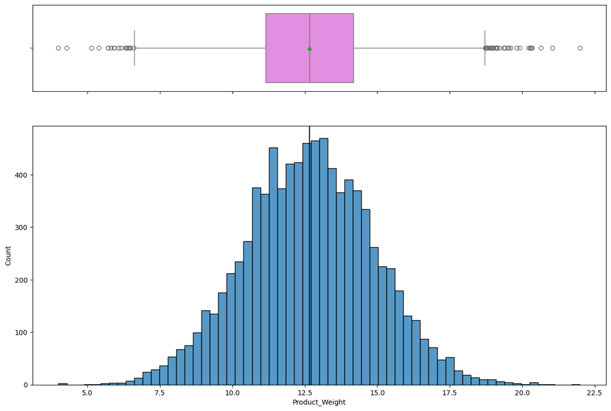

```python
histogram_boxplot(df, "Product_Weight")
```

# **Observations:**

The boxplot shows a few outliers on both ends, but most product weights are within a consistent range. The histogram suggests a normal distribution centered around the mean (~12.65), indicating product weights are relatively evenly distributed around this value.

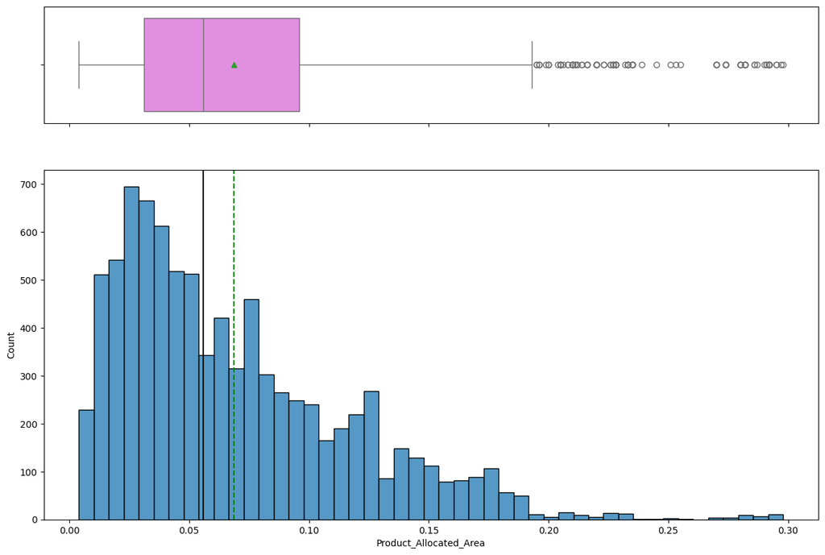

```python
histogram_boxplot(df, "Product_Allocated_Area")
```

# **Observations:**

The boxplot shows several outliers, particularly on the higher end, indicating some products have a disproportionately large allocated area. The histogram indicates a right-skewed distribution. Most products have a smaller allocated area, with a few having significantly larger areas.

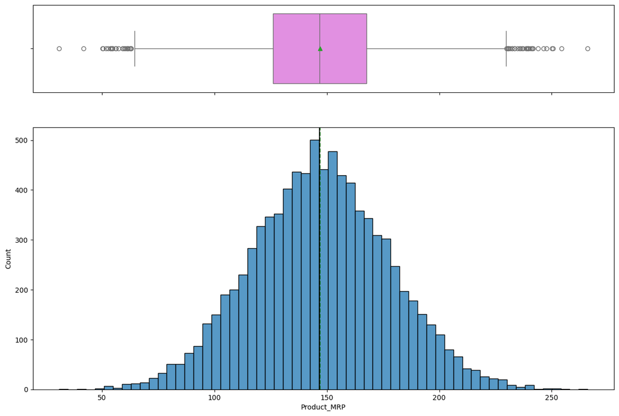

```python
histogram_boxplot(df, "Product_MRP")
```

# **Observations:**

The boxplot indicates a few outliers on both the lower and higher ends, with most values clustered in the interquartile range. The histogram shows a normal distribution centered around the mean (~147), with a few products priced significantly lower or higher.

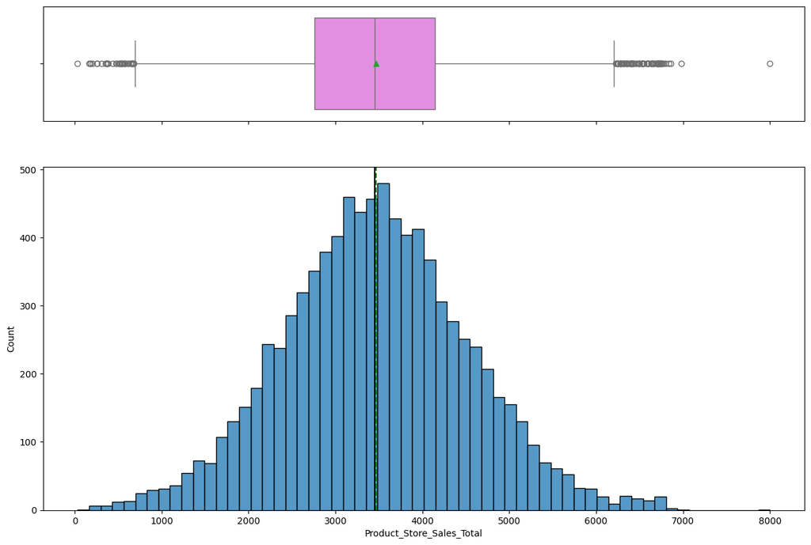

```python
histogram_boxplot(df, "Product_Store_Sales_Total")
```

# **Observations:**

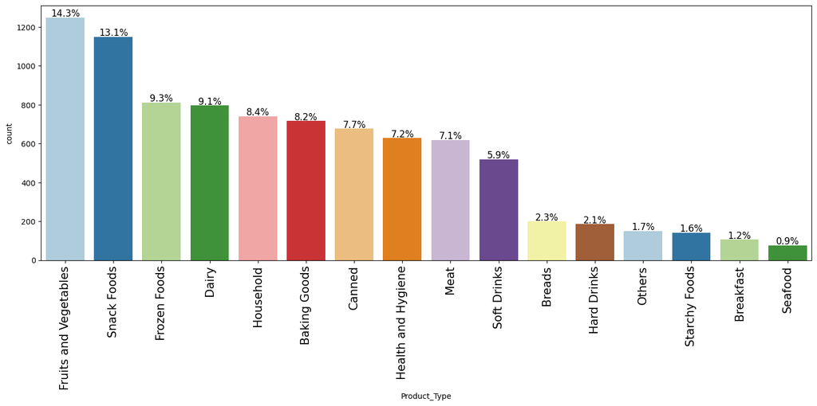

```python
labeled_barplot(df, "Product_Type", perc=True)
```

# **Observations:**

Most of the product are 'Fruits and Vegetables' with 14.3% followed by 'Snack Foods' with 13.1%, 'Frozen Foods' with 9.3%, 'Dairy' with 9.1% and so on with other product types. The least type is 'Seafood' with only 0.9%

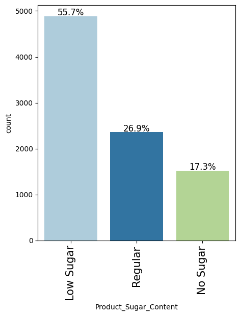

```python
# Product distribution as per Sugar content

labeled_barplot(df, "Product_Sugar_Content", perc=True)
```

# **Observations:**

Majority of products are low sugar, indicating a potential market preference or health trend that could influence inventory and marketing decisions.

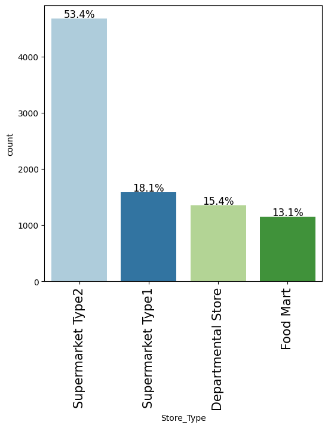

```python
# Count of Store Type

labeled_barplot(df, "Store_Type", perc=True)
```

# **Observations:**

The focus on Supermarket Type 2 indicates a predominant store format, which could shape the overall business strategy and customer experience initiatives.

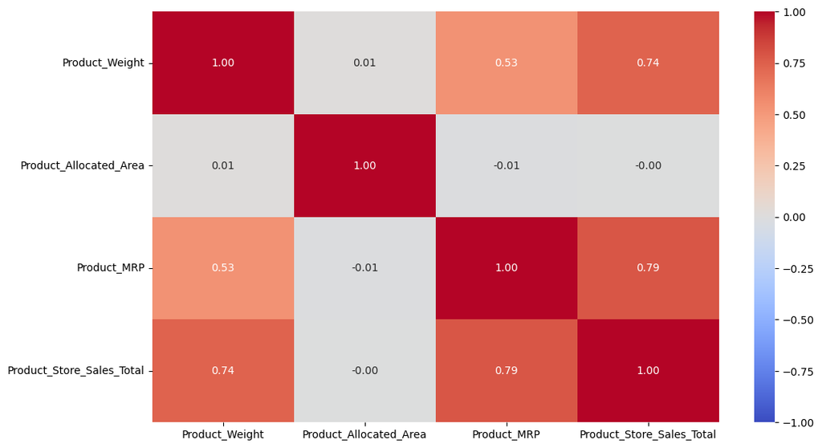

```python
#Correlation Analysis

# creating a list of numerical columns
num_cols = df.select_dtypes(include=np.number).columns.tolist()

# dropping start and finish year from list of numerical columns as they are not numerical in nature
num_cols.remove("Store_Establishment_Year")

plt.figure(figsize=(12, 7))
sns.heatmap(
    df[num_cols].corr(), annot=True, vmin=-1, vmax=1, fmt=".2f", cmap="coolwarm"
)
plt.show()
```

# **Observations:**

From the above heatmap, we can say that 'Product_Weight', 'Product_MRP', is highly corelated to 'Product_Store_Sales_Total'. Also 'Product_Weight' is slightly correlated to 'Product_MRP'.

**Product_Weight:**

Strong positive correlation with Product_Store_Sales_Total (0.74), indicating that higher product weights are associated with higher total sales.

Moderate positive correlation with Product_MRP (0.53), suggesting that heavier products tend to have higher maximum retail prices.

**Product_Allocated_Area:**

Negligible correlations with other variables, indicating that the allocated display area does not significantly impact other numerical features.

**Product_MRP:**

Strong positive correlation with Product_Store_Sales_Total (0.79), showing that products with higher MRPs contribute more to total sales. Moderate positive correlation with Product_Weight (0.53), reinforcing the relationship between product weight and retail price.

**Store_Establishment_Year:**

**Product_Store_Sales_Total:**

Strong positive correlations with Product_Weight (0.74) and Product_MRP (0.79), indicating that both higher weights and higher prices are significant contributors to total sales.

**Summary**

## Bivariate Analysis

```
The product type contributing the most to the revenue is: Fruits and Vegetables
Sales amount for the top product type: 4300833.27
```

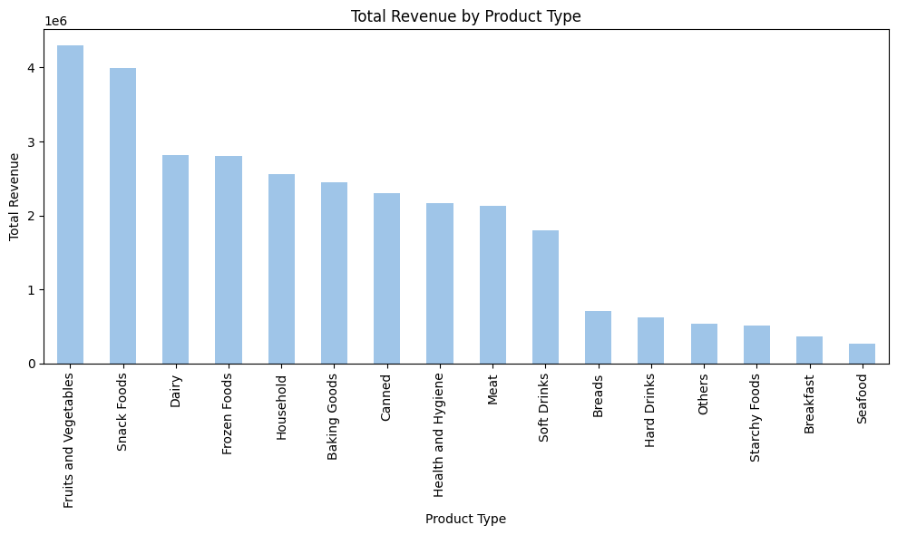

```python
# Finding out which product type is contributing most to the revenue of the company

import pandas as pd

# Group by 'Product_Type' and sum the 'Product_Store_Sales_Total' for each product type
revenue_by_product_type = df.groupby('Product_Type')['Product_Store_Sales_Total'].sum()

# Sort the result in descending order to find the product type with the highest revenue
sorted_revenue = revenue_by_product_type.sort_values(ascending=False)

# Find the product type with the highest revenue
top_product_type = revenue_by_product_type.idxmax()
top_product_sales_amount = revenue_by_product_type.max()

print(f"The product type contributing the most to the revenue is: {top_product_type}")
print(f"Sales amount for the top product type: {top_product_sales_amount:.2f}")


# Create a bar plot
plt.figure(figsize=(10, 6))
sorted_revenue.plot(kind='bar', color=['#9fc5e8'])
plt.xlabel('Product Type')
plt.ylabel('Total Revenue')
plt.title('Total Revenue by Product Type')
plt.xticks(rotation=90)
plt.tight_layout()
plt.show()
```

# **Observations:**

**Top Revenue Contributor:** The product type contributing the most to the revenue is: Fruits and Vegetables with sales amount of $4300833.27

```
The type of store with the greatest revenue is Supermarket Type2
Overall sales for the best store type is 15427583.43
The location which generates the highest amount of revenue is Tier 2
Revenue for the top location type is 21650696.61
```

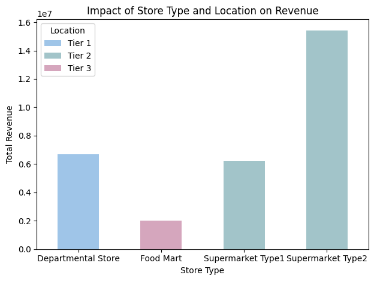

```python
#ocation may have a high impact on the revenue of a store. Finding out the type of stores and locations that are having a high impact on the revenue of the company.

# Group by 'Store_Type' and calculate the average revenue for each store type
store_type_revenue = df.groupby('Store_Type')['Product_Store_Sales_Total'].sum()

# Group by 'Store_Location_City_Type' and calculate the average revenue for each location
location_revenue = df.groupby('Store_Location_City_Type')['Product_Store_Sales_Total'].sum()

# Find the store type and location with the highest average revenue
top_store_type = store_type_revenue.idxmax()
top_store_type_revenue = store_type_revenue.max()

top_location = location_revenue.idxmax()
top_location_revenue = location_revenue.max()

print(f"The type of store with the greatest revenue is {top_store_type}")
print(f"Overall sales for the best store type is {top_store_type_revenue:.2f}")

print(f"The location which generates the highest amount of revenue is {top_location}")
print(f"Revenue for the top location type is {top_location_revenue:.2f}")

# Creating a pivot
store_location_revenue = df.pivot_table(index='Store_Type', columns='Store_Location_City_Type', values='Product_Store_Sales_Total', aggfunc='sum')

# Create a bar plot
plt.figure(figsize=(12, 6))
store_location_revenue.plot(kind='bar', stacked=True, color=['#9fc5e8', '#a2c4c9', '#d5a6bd'])
plt.xlabel('Store Type')
plt.ylabel('Total Revenue')
plt.title('Impact of Store Type and Location on Revenue')
plt.xticks(rotation=0)
plt.legend(title='Location')
plt.tight_layout()
plt.show()
```

# **Observations:**

**Type of stores and locations with high impact on the revenue:** Supermarket Type 2 is the store type with the highest revenue. The top store type has an overall sales of USD 15427583.43. Tier 2 is the location where the most revenue is made. The revenue for top location type is USD 21650696.61

```
Product_Type
Fruits and Vegetables    864
Snack Foods              804
Dairy                    590
Frozen Foods             531
Baking Goods             462
Canned                   402
Meat                     377
Soft Drinks              370
Breads                   148
Hard Drinks              128
Starchy Foods             97
Breakfast                 65
Seafood                   47
Name: Product_Store_Sales_Total, dtype: int64
```

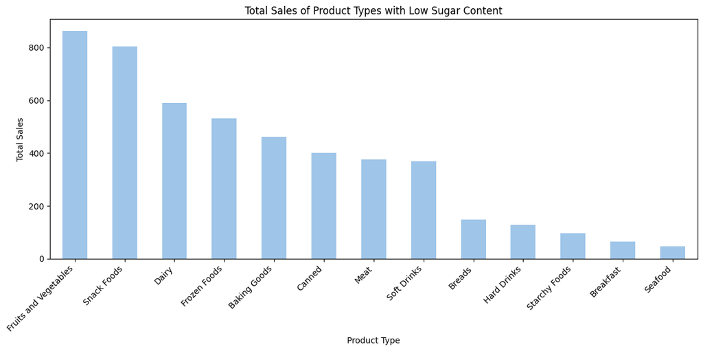

```python
# Filter the DataFrame to rows with 'Product_Sugar_Content' set to 'Low'.
low_sugar_df = df[df['Product_Sugar_Content'] == 'Low Sugar']

# Count the quantity of each product type sold after grouping by 'Product_Type'
items_sold_by_product_type = low_sugar_df.groupby('Product_Type')['Product_Store_Sales_Total'].count().sort_values(ascending=False)

print(items_sold_by_product_type)

# Create a bar plot
plt.figure(figsize=(12, 6))
items_sold_by_product_type.plot(kind='bar', color=['#9fc5e8'])
plt.xlabel('Product Type')
plt.ylabel('Total Sales')
plt.title('Total Sales of Product Types with Low Sugar Content')
plt.xticks(rotation=45, ha='right')
plt.tight_layout()
plt.show()
```

# **Observations:**

We can see that The category "Fruits and Vegetables" saw sales of 864 items. 804 items were sold under the "Snack Foods" category. 590 products under the "Dairy" category were sold. The "Frozen Foods" category had sales of 531 different items overall. 462 products in the "Baking Goods" category were sold. The "Canned" category saw the sale of 402 goods. There were 377 sales of "Meat" products. There were 370 goods sold under the "Soft Drinks" category. 148 products in the "Breads" category were sold. 128 items fell under the "Hard Drinks" category and were sold. There were 97 products marketed under the "Starchy Foods" category. There were 65 sales in the "Breakfast" category. Finally, 47 goods were sold under the "Seafood" category.

```
Product type sold the most number of times in each store:
Store_Id
OUT001              (OUT001, Snack Foods)
OUT002    (OUT002, Fruits and Vegetables)
OUT003              (OUT003, Snack Foods)
OUT004    (OUT004, Fruits and Vegetables)
Name: Product_Store_Sales_Total, dtype: object

Product type contributing the most to the revenue of each store:
Store_Id
OUT001              (OUT001, Snack Foods)
OUT002    (OUT002, Fruits and Vegetables)
OUT003              (OUT003, Snack Foods)
OUT004    (OUT004, Fruits and Vegetables)
Name: Product_Store_Sales_Total, dtype: object
```

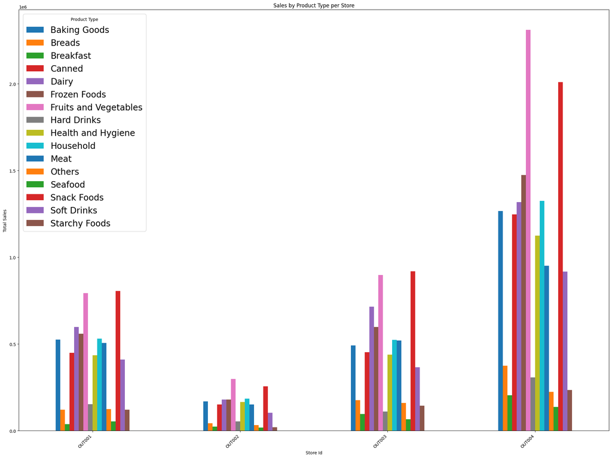

```python
#Finding which product type is contributing the most to the revenue of the individual stores

# Group by 'Store_Id' and 'Product_Type' to get the count of sales of each product type sold in each store
product_count_by_store = df.groupby(['Store_Id', 'Product_Type'])['Product_Store_Sales_Total'].count()

# Find the product type that has been sold the most number of times in each store
max_sold_product_by_store = product_count_by_store.groupby(level='Store_Id').idxmax()

print("Product type sold the most number of times in each store:")
print(max_sold_product_by_store)

# Group by 'Store_Id' and 'Product_Type' to get the total revenue of each product type in each store
revenue_by_product_type = df.groupby(['Store_Id', 'Product_Type'])['Product_Store_Sales_Total'].sum()

# Find the product type that is contributing the most to the revenue of each store
top_revenue_product_by_store = revenue_by_product_type.groupby(level='Store_Id').idxmax()

print("\nProduct type contributing the most to the revenue of each store:")
print(top_revenue_product_by_store)

sales_by_product_type_per_store = df.groupby(['Store_Id', 'Product_Type'])['Product_Store_Sales_Total'].sum().unstack()

# Plot the sales by product type per store using a grouped bar plot
fig, ax = plt.subplots(figsize=(20, 15))

# Plot the sales by product type per store using a grouped bar plot
sales_by_product_type_per_store.plot(kind='bar', ax=ax)
ax.set_xlabel('Store Id')
ax.set_ylabel('Total Sales')
ax.set_title('Sales by Product Type per Store')
ax.set_xticklabels(sales_by_product_type_per_store.index, rotation=45, ha='right')

# Adjust legend size
legend = ax.legend(title='Product Type', prop={'size': 20})

plt.tight_layout()
plt.show()
```

# **Observations:**

**The product type that is contributing the most to the revenue of the individual stores:** Snack Foods are the product type sold most frequently at the OUT001 store. Fruits and vegetables are the product category that OUT002 store sells the most of. Snack Foods are the product category that OUT003 store sells the most of. Fruits and vegetables are the product category that OUT004 store sells the most of. Similarly, Snack Foods is the product category that generates the most of the revenue for the OUT001 store. Fruits and vegetables are the product category for the OUT002 store that contributes the most to revenue. Snack Foods are the product category for the OUT003 store that generates the largest amount of revenue. Fruits and vegetables are the product category for the OUT004 store that contributes the most to revenue.

```
Store with highest average MRP: OUT003
```

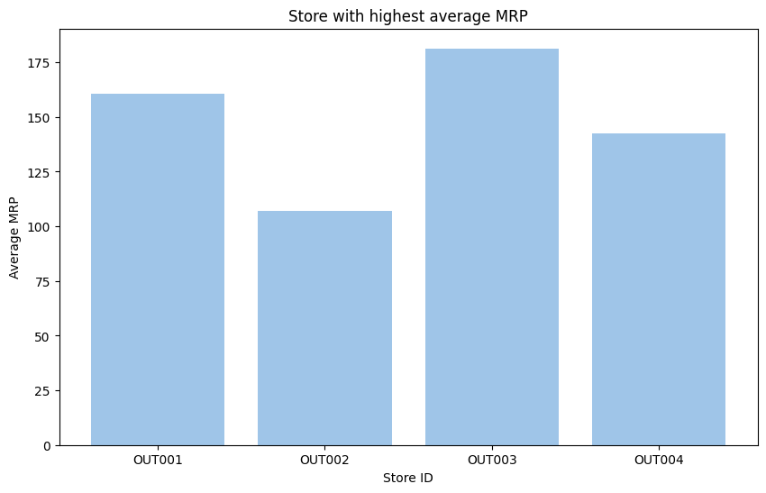

```python
#Finding which store has sold more costly goods than others

# Group by Store_Id and calculating the average MRP for each store
store_average_mrp = df.groupby('Store_Id')['Product_MRP'].mean()

# Finding the store with the highest average MRP
highest_avg_mrp_store = store_average_mrp.idxmax()

print("Store with highest average MRP:", highest_avg_mrp_store)

# Highlight the store with the highest average MRP
plt.figure(figsize=(10, 6))
plt.bar(store_average_mrp.index, store_average_mrp.values, color='#9fc5e8')
plt.xlabel('Store ID')
plt.ylabel('Average MRP')
plt.title('Store with highest average MRP')
```

# **Observations:**

On an average, store id OUT003 sells higher priced items then others.

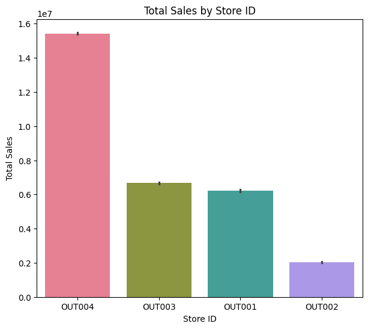

```python
# Plot 'Store_Id' on the target feature. Define the colors
colors= sns.color_palette('husl', df['Store_Id'].nunique())

# Plot the data
plt.figure(figsize= (7,6))
sns.barplot(data= df, x= 'Store_Id', y= 'Product_Store_Sales_Total', estimator= np.sum, palette= colors)
plt.xlabel('Store ID')
plt.ylabel('Total Sales')
plt.title('Total Sales by Store ID')
plt.show()
```

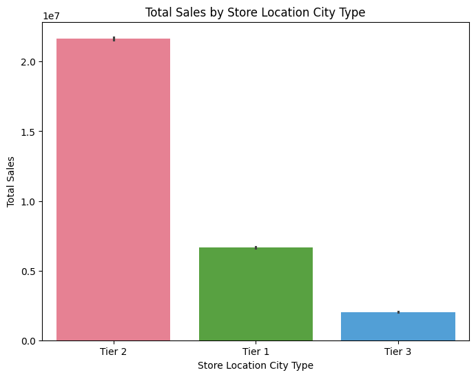

```python
# Plot 'Store_Location_City_Type' on the target feature. Define the colors
colors= sns.color_palette('husl', df['Store_Location_City_Type'].nunique())

# Plot the data
plt.figure(figsize= (8,6))
sns.barplot(data= df, x= 'Store_Location_City_Type', y= 'Product_Store_Sales_Total', estimator= np.sum, palette= colors)
plt.xlabel('Store Location City Type')
plt.ylabel('Total Sales')
plt.title('Total Sales by Store Location City Type')
plt.show()
```

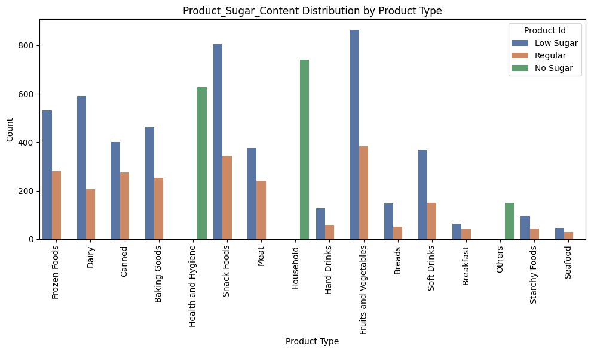

```python
# Product Type vs Sugar Content Consumption

# Create a count plot for Product_Id against Product_Type
plt.figure(figsize=(10, 6))
sns.countplot(data=df, x='Product_Type', hue='Product_Sugar_Content', palette='deep')
plt.xlabel('Product Type')
plt.ylabel('Count')
plt.title('Product_Sugar_Content Distribution by Product Type')
plt.xticks(rotation=90)
plt.legend(title='Product Id')
plt.tight_layout()

plt.show()
```

# **Observations:**

Most of the product type has low sugar content.

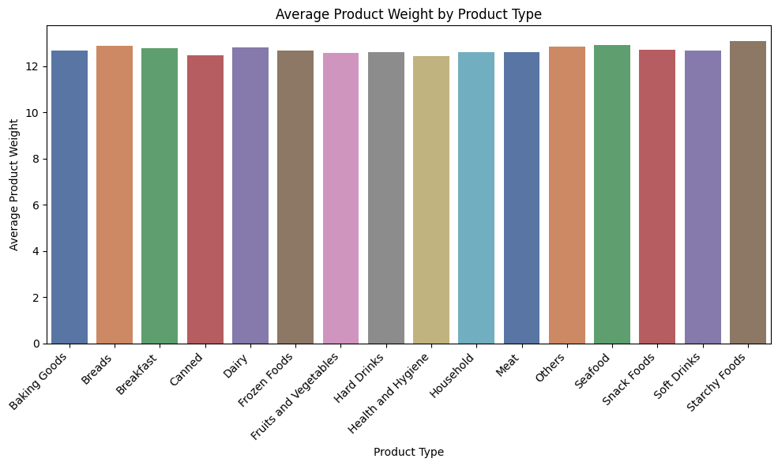

```python
# Product Type vs Average Product Weight

average_weight_by_type = df.groupby('Product_Type')['Product_Weight'].mean().reset_index()

plt.figure(figsize=(10, 6))
sns.barplot(data=average_weight_by_type, x='Product_Type', y='Product_Weight', palette='deep')
plt.xticks(rotation=45, ha='right')
plt.xlabel('Product Type')
plt.ylabel('Average Product Weight')
plt.title('Average Product Weight by Product Type')
plt.tight_layout()
plt.show()
```

# **Observations:**

There is not much difference across various product type for average product weight. Starchy foods has the highest product weight followed by sea food and breads

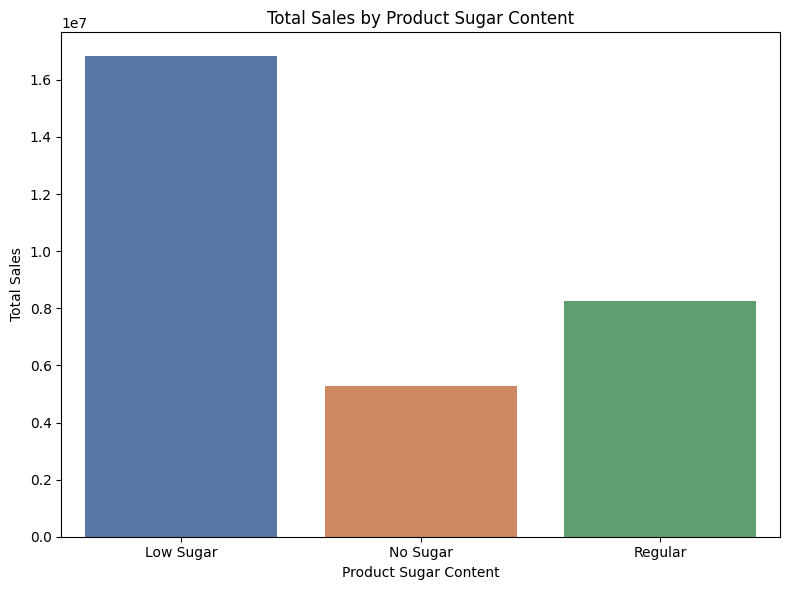

```python
# Total Sales as per Sugar content

# Calculate total Product_Store_Sales_Total for each Product_Sugar_Content
total_sales_by_sugar_content = df.groupby('Product_Sugar_Content')['Product_Store_Sales_Total'].sum().reset_index()

plt.figure(figsize=(8, 6))
sns.barplot(data=total_sales_by_sugar_content, x='Product_Sugar_Content', y='Product_Store_Sales_Total', palette='deep')
plt.xlabel('Product Sugar Content')
plt.ylabel('Total Sales')
plt.title('Total Sales by Product Sugar Content')
plt.tight_layout()
plt.show()
```

# **Observations:**

Products with low sugar content has the highest amount of sales.

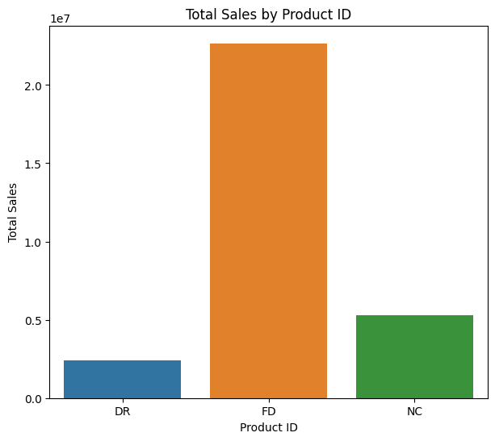

```python
# Plot 'Product_Id' on the target feature. Define the colors
colors= ['#1f77b4', '#ff7f0e', '#2ca02c']

# Calculate total Product_Store_Sales_Total for each Product_Sugar_Content
df_rev= df.groupby(['Product_Id'])['Product_Store_Sales_Total'].sum().reset_index()

# Plot the data
plt.figure(figsize= (7,6))
sns.barplot(data= df_rev, x= 'Product_Id', y= 'Product_Store_Sales_Total', palette= colors)
plt.xlabel('Product ID')
plt.ylabel('Total Sales')
plt.title('Total Sales by Product ID')
plt.show()
```

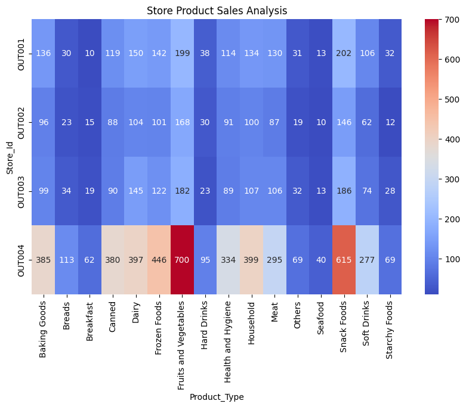

```python
# Store product analysis
plt.figure(figsize= (10,6))
sns.heatmap(pd.crosstab(df['Store_Id'], df['Product_Type']), annot= True, cmap= 'coolwarm', fmt= 'g')
plt.title('Store Product Sales Analysis')
```

# **Heat Map Analysis - Store ID vs Product Type**

**Store OUT004 Dominance:**

Store OUT004 has significantly higher counts across most product types compared to other stores. Notably, Frozen Foods, Fruits and Vegetables, Dairy, and Snack Foods have the highest counts in this store.

**Popular Product Types:**

**Least Popular Product Types:**

Seafood and Breads are among the least common product types across all stores, with relatively low counts. The counts for these product types are consistently lower across all stores, suggesting lower demand or inventory levels.

**Inter-store Variation:**

There is noticeable variation in product type counts between different stores. For example, OUT001 has a high count of Frozen Foods and Dairy, while OUT002 has more balanced distribution across different product types. Consistency Across Stores:

**Store Size and Inventory:**

The variation in product counts indicates differences in store sizes or stocking policies. Stores like OUT004 may be larger or have higher customer traffic, leading to higher inventory levels. Smaller stores or those with less traffic (like OUT002) show lower counts across most product types.

**Customer Preferences:**

The data suggests that customer preferences vary by location. Stores with higher counts for certain product types might be catering to specific customer demands in those areas.

**Potential for Inventory Optimization:**

Stores with lower counts for certain popular products might need to adjust their inventory to meet potential demand. Stores with high counts for less popular items might benefit from reallocating shelf space to higher-demand products.

**Sales and Revenue Implications:**

Higher inventory levels for certain products in stores like OUT004 suggest potential for higher sales and revenue.

# **Data Preprocessing**

```python
# Create 'Store_Age' column
df['Store_Age']= 2023 - df['Store_Establishment_Year']
df.drop(columns= ['Store_Establishment_Year'], axis= 0, inplace= True)

# Verify changes
df.head()
```

|  | Product_Id | Product_Weight | Product_Sugar_Content | Product_Allocated_Area | Product_Type | Product_MRP | Store_Id | Store_Size | Store_Location_City_Type | Store_Type | Product_Store_Sales_Total | Store_Age |
| --- | --- | --- | --- | --- | --- | --- | --- | --- | --- | --- | --- | --- |
| 0 | FD | 12.66 | Low Sugar | 0.027 | Frozen Foods | 117.08 | OUT004 | Medium | Tier 2 | Supermarket Type2 | 2842.40 | 14 |
| 1 | FD | 16.54 | Low Sugar | 0.144 | Dairy | 171.43 | OUT003 | Medium | Tier 1 | Departmental Store | 4830.02 | 24 |
| 2 | FD | 14.28 | Regular | 0.031 | Canned | 162.08 | OUT001 | High | Tier 2 | Supermarket Type1 | 4130.16 | 36 |
| 3 | FD | 12.10 | Low Sugar | 0.112 | Baking Goods | 186.31 | OUT001 | High | Tier 2 | Supermarket Type1 | 4132.18 | 36 |
| 4 | NC | 9.57 | No Sugar | 0.010 | Health and Hygiene | 123.67 | OUT002 | Small | Tier 3 | Food Mart | 2279.36 | 25 |

```python
# View product types
df['Product_Type'].value_counts().index.to_list()
```

```
['Fruits and Vegetables',
 'Snack Foods',
 'Frozen Foods',
 'Dairy',
 'Household',
 'Baking Goods',
 'Canned',
 'Health and Hygiene',
 'Meat',
 'Soft Drinks',
 'Breads',
 'Hard Drinks',
 'Others',
 'Starchy Foods',
 'Breakfast',
 'Seafood']
```

```python
# Define a mapping of original categories to new grouped categories
category_mapping= {
    'Fruits and Vegetables': 'Food Items',
    'Snack Foods': 'Food Items',
    'Frozen Foods': 'Food Items',
    'Dairy': 'Food Items',
    'Baking Goods': 'Food Items',
    'Canned': 'Food Items',
    'Meat': 'Food Items',
    'Breads': 'Food Items',
    'Breakfast': 'Food Items',
    'Seafood': 'Food Items',
    'Soft Drinks': 'Beverages',
    'Hard Drinks': 'Beverages',
    'Household': 'Household and Hygiene',
    'Health and Hygiene': 'Household and Hygiene',
    'Others': 'Miscellaneous',
    'Starchy Foods': 'Miscellaneous'
}

# Apply the mapping to create a new feature
df['Grouped_Product_Type']= df['Product_Type'].map(category_mapping)

# Verify the changes
df['Grouped_Product_Type'].value_counts()
```

| Grouped_Product_Type | count |
| --- | --- |
| Food Items | 6398 |
| Household and Hygiene | 1368 |
| Beverages | 705 |
| Miscellaneous | 292 |

**dtype:** int64

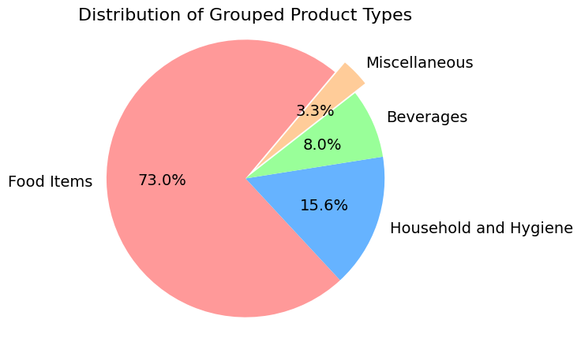

```python
# 'Grouped_Product_Type' Pie chart
grouped_counts= {
    'Food Items': 6398,
    'Household and Hygiene': 1368,
    'Beverages': 705,
    'Miscellaneous': 292
}

# Labels and sizes for the pie chart
labels= list(grouped_counts.keys())
sizes= list(grouped_counts.values())

# Colors for the pie chart
colors= ['#ff9999','#66b3ff','#99ff99','#ffcc99']

# Explode 'Miscellaneous' slice
explode= [0, 0, 0, 0.1]

# Plotting the pie chart
plt.figure(figsize= (5,5))
plt.pie(sizes, labels= labels, colors= colors, autopct= '%1.1f%%', startangle= 50, explode= explode, textprops= {'fontsize': 14})
plt.axis('equal')
plt.title('Distribution of Grouped Product Types', fontsize= 16)
plt.show()
```

```python
# Drop the 'Product_Type' column since we now have Grouped Product type column
df.drop(columns= ['Product_Type'], inplace= True)

# Verify changes
df.head()
```

|  | Product_Id | Product_Weight | Product_Sugar_Content | Product_Allocated_Area | Product_MRP | Store_Id | Store_Size | Store_Location_City_Type | Store_Type | Product_Store_Sales_Total | Store_Age | Grouped_Product_Type |
| --- | --- | --- | --- | --- | --- | --- | --- | --- | --- | --- | --- | --- |
| 0 | FD | 12.66 | Low Sugar | 0.027 | 117.08 | OUT004 | Medium | Tier 2 | Supermarket Type2 | 2842.40 | 14 | Food Items |
| 1 | FD | 16.54 | Low Sugar | 0.144 | 171.43 | OUT003 | Medium | Tier 1 | Departmental Store | 4830.02 | 24 | Food Items |
| 2 | FD | 14.28 | Regular | 0.031 | 162.08 | OUT001 | High | Tier 2 | Supermarket Type1 | 4130.16 | 36 | Food Items |
| 3 | FD | 12.10 | Low Sugar | 0.112 | 186.31 | OUT001 | High | Tier 2 | Supermarket Type1 | 4132.18 | 36 | Food Items |
| 4 | NC | 9.57 | No Sugar | 0.010 | 123.67 | OUT002 | Small | Tier 3 | Food Mart | 2279.36 | 25 | Household and Hygiene |

```python
# Define all numeric columns
num_cols= df.select_dtypes(include= np.number).columns.to_list()
num_cols
```

```
['Product_Weight',
 'Product_Allocated_Area',
 'Product_MRP',
 'Product_Store_Sales_Total',
 'Store_Age']
```

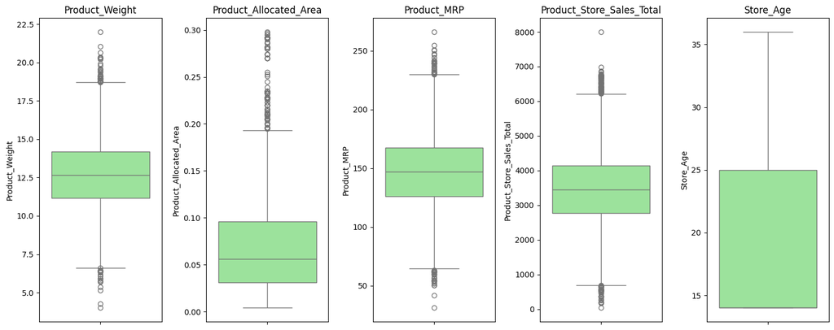

```python
# Plot numeric columns to visualize outliers
fig, ax= plt.subplots(1, len(num_cols), figsize= (15,6))

# Define color
color= 'lightgreen'

for j, col in enumerate(num_cols):
  sns.boxplot(df[col], ax= ax[j], color= color).set(title= col)

plt.tight_layout()
plt.show()
```

# **Observations:**

After reviewing the boxplots for the numeric features, I observed outliers in Product_Weight, Product_Allocated_Area, and Product_MRP. I have decided not to remove or transform these outliers because:

Product_Weight: The variation in product weights is natural and expected. Product_Allocated_Area: Differences in display areas are normal due to diverse store layouts. Product_MRP: Price variations are common and reflect the diversity in product pricing. For Store_Age, which represents store age, and the target feature Product_Store_Sales_Total, no adjustments are needed.

These outliers are normal and represent real-world scenarios, so I will retain them.

```python
df[num_cols].describe()
```

|  | Product_Weight | Product_Allocated_Area | Product_MRP | Product_Store_Sales_Total | Store_Age |
| --- | --- | --- | --- | --- | --- |
| count | 8763.000000 | 8763.000000 | 8763.000000 | 8763.000000 | 8763.000000 |
| mean | 12.653792 | 0.068786 | 147.032539 | 3464.003640 | 20.967249 |
| std | 2.217320 | 0.048204 | 30.694110 | 1065.630494 | 8.388381 |
| min | 4.000000 | 0.004000 | 31.000000 | 33.000000 | 14.000000 |
| 25% | 11.150000 | 0.031000 | 126.160000 | 2761.715000 | 14.000000 |
| 50% | 12.660000 | 0.056000 | 146.740000 | 3452.340000 | 14.000000 |
| 75% | 14.180000 | 0.096000 | 167.585000 | 4145.165000 | 25.000000 |
| max | 22.000000 | 0.298000 | 266.000000 | 8000.000000 | 36.000000 |

```python
# Checking unique values for categorical variables

# list of all categorical variables
cat_col = df.select_dtypes(include="object").columns.tolist()

# printing the number of occurrences of each unique value in each categorical column
for column in cat_col:
    print(df[column].value_counts(normalize=True))
    print("-" * 50)
```

```
Product_Id
FD    0.746206
NC    0.173342
DR    0.080452
Name: proportion, dtype: float64
--------------------------------------------------
Product_Sugar_Content
Low Sugar    0.557457
Regular      0.269200
No Sugar     0.173342
Name: proportion, dtype: float64
--------------------------------------------------
Store_Id
OUT004    0.533607
OUT001    0.180988
OUT003    0.153943
OUT002    0.131462
Name: proportion, dtype: float64
--------------------------------------------------
Store_Size
Medium    0.687550
High      0.180988
Small     0.131462
Name: proportion, dtype: float64
--------------------------------------------------
Store_Location_City_Type
Tier 2    0.714595
Tier 1    0.153943
Tier 3    0.131462
Name: proportion, dtype: float64
--------------------------------------------------
Store_Type
Supermarket Type2     0.533607
Supermarket Type1     0.180988
Departmental Store    0.153943
Food Mart             0.131462
Name: proportion, dtype: float64
--------------------------------------------------
Grouped_Product_Type
Food Items               0.730115
Household and Hygiene    0.156111
Beverages                0.080452
Miscellaneous            0.033322
Name: proportion, dtype: float64
--------------------------------------------------
```

# **Observations:**

Product ID starting with FD is available in stores most.

Products with low sugar are heavily stocked

Store ID, OUT004 has the most number of products

Medium sized stores are listed more in the dataset

Tier 2 cities have more data in the dataset when compared with Tier 1 and Tier 3

Supermarket Type2 has the most products

Among all the products in the data set Food items are the most prevalent product type

```python
df_model = df.copy()
```

```python
# Define features (X) and target (y)
X = df_model.drop("Product_Store_Sales_Total", axis=1)  # Drop the target column to get features
y = df_model["Product_Store_Sales_Total"]

print(X.head())
print(y.head())
```

```
  Product_Id  Product_Weight Product_Sugar_Content  Product_Allocated_Area  \
0         FD           12.66             Low Sugar                   0.027
1         FD           16.54             Low Sugar                   0.144
2         FD           14.28               Regular                   0.031
3         FD           12.10             Low Sugar                   0.112
4         NC            9.57              No Sugar                   0.010

   Product_MRP Store_Id Store_Size Store_Location_City_Type  \
0       117.08   OUT004     Medium                   Tier 2
1       171.43   OUT003     Medium                   Tier 1
2       162.08   OUT001       High                   Tier 2
3       186.31   OUT001       High                   Tier 2
4       123.67   OUT002      Small                   Tier 3

           Store_Type  Store_Age   Grouped_Product_Type
0   Supermarket Type2         14             Food Items
1  Departmental Store         24             Food Items
2   Supermarket Type1         36             Food Items
3   Supermarket Type1         36             Food Items
4           Food Mart         25  Household and Hygiene
0    2842.40
1    4830.02
2    4130.16
3    4132.18
4    2279.36
Name: Product_Store_Sales_Total, dtype: float64
```

```python
# Split the dataset into training and test sets
X_train, X_test, y_train, y_test = train_test_split(
    X, y,              # Predictors (X) and target variable (y)
    test_size=0.2,     # 20% of the data is reserved for testing
    random_state=42    # Ensures reproducibility by setting a fixed random seed
)
```

```python
# Define numerical features for preprocessing (excluding the target)
numerical_features = X.select_dtypes(include=np.number).columns.tolist()
numerical_features
```

```
['Product_Weight', 'Product_Allocated_Area', 'Product_MRP', 'Store_Age']
```

```python
# Create a preprocessing pipeline for numerical and categorical features
preprocessor = make_column_transformer(
    (Pipeline([('num_imputer', SimpleImputer(strategy='median')),
               ('scaler', StandardScaler())]), numerical_features),
    (Pipeline([('cat_imputer', SimpleImputer(strategy='most_frequent')),
               ('encoder', OneHotEncoder(handle_unknown='ignore'))]), cat_col)
)
```

```python
# function to compute adjusted R-squared
def adj_r2_score(predictors, targets, predictions):
    r2 = r2_score(targets, predictions)
    n = predictors.shape[0]
    k = predictors.shape[1]
    return 1 - ((1 - r2) * (n - 1) / (n - k - 1))


# function to compute different metrics to check performance of a regression model
def model_performance_regression(model, predictors, target):
    """
    Function to compute different metrics to check regression model performance

    model: regressor
    predictors: independent variables
    target: dependent variable
    """

    # predicting using the independent variables
    pred = model.predict(predictors)

    r2 = r2_score(target, pred)  # to compute R-squared
    adjr2 = adj_r2_score(predictors, target, pred)  # to compute adjusted R-squared
    rmse = np.sqrt(mean_squared_error(target, pred))  # to compute RMSE
    mae = mean_absolute_error(target, pred)  # to compute MAE
    mape = mean_absolute_percentage_error(target, pred)  # to compute MAPE

    # creating a dataframe of metrics
    df_perf = pd.DataFrame(
        {
            "RMSE": rmse,
            "MAE": mae,
            "R-squared": r2,
            "Adj. R-squared": adjr2,
            "MAPE": mape,
        },
        index=[0],
    )

    return df_perf
```

# **Model Building**

## Define functions for Model Evaluation

The ML models to be built can be any two out of the following:

1. Decision Tree
2. Bagging
3. Random Forest
4. AdaBoost
5. Gradient Boosting
6. XGBoost

# **Random Forest Regressor**

```python
# Define base Random Forest model
rf_model = RandomForestRegressor(random_state=42)
```

```python
# Create pipeline with preprocessing and Random Forest model
rf_pipeline = make_pipeline(preprocessor, rf_model)
```

```python
# Train the model pipeline on the training data
rf_pipeline.fit(X_train, y_train)
```

```
Pipeline(steps=[('columntransformer',
                 ColumnTransformer(transformers=[('pipeline-1',
                                                  Pipeline(steps=[('num_imputer',
                                                                   SimpleImputer(strategy='median')),
                                                                  ('scaler',
                                                                   StandardScaler())]),
                                                  ['Product_Weight',
                                                   'Product_Allocated_Area',
                                                   'Product_MRP',
                                                   'Store_Age']),
                                                 ('pipeline-2',
                                                  Pipeline(steps=[('cat_imputer',
                                                                   SimpleImputer(strategy='most_frequent')),
                                                                  ('encoder',
                                                                   OneHotEncoder(handle_unknown='ignore'))]),
                                                  ['Product_Id',
                                                   'Product_Sugar_Content',
                                                   'Store_Id', 'Store_Size',
                                                   'Store_Location_City_Type',
                                                   'Store_Type',
                                                   'Grouped_Product_Type'])])),
                ('randomforestregressor',
                 RandomForestRegressor(random_state=42))])
```

```python
from google.colab import drive
drive.mount('/content/drive')
```

```python
rf_estimator_model_train_perf = model_performance_regression(rf_pipeline, X_train,y_train)
print("Training performance \n")
rf_estimator_model_train_perf
```

```
Training performance
```

|  | RMSE | MAE | R-squared | Adj. R-squared | MAPE |
| --- | --- | --- | --- | --- | --- |
| 0 | 107.407044 | 40.424329 | 0.989827 | 0.989811 | 0.014903 |

```python
rf_estimator_model_test_perf = model_performance_regression(rf_pipeline, X_test,y_test)
print("Testing performance \n")
rf_estimator_model_test_perf
```

```
Testing performance
```

|  | RMSE | MAE | R-squared | Adj. R-squared | MAPE |
| --- | --- | --- | --- | --- | --- |
| 0 | 286.191506 | 109.562423 | 0.928217 | 0.927764 | 0.039133 |

# **Observations:**

The model fits the training data extremely well. An R² of 0.989 means 98.9% of variance is explained. The very low MAPE (1.49%) indicates highly accurate predictions on the training set.

Performance drops on test data, but it’s still strong:

R² of 0.928 means ~92.8% of variance is explained.

MAPE of 3.9% is still very good.

The train and test performance suggest moderate overfitting, as:

Error more than doubles (RMSE)

R² drops by ~6%

MAPE increases ~2.6×

However, the test performance is still strong overall.

# **Model Performance Improvement - Hyperparameter Tuning - Random Forest Regressor**

```python
# Choose the type of classifier.
rf_tuned = RandomForestRegressor(random_state=42)

# Create pipeline with preprocessing and XGBoost model
rf_pipeline = make_pipeline(preprocessor, rf_tuned)

# Grid of parameters to choose from
parameters = parameters = {
    'randomforestregressor__max_depth':[3, 4, 5, 6],
    'randomforestregressor__max_features': ['sqrt','log2',None],
    'randomforestregressor__n_estimators': [50, 75, 100, 125, 150]
}

# Type of scoring used to compare parameter combinations
scorer = metrics.make_scorer(metrics.r2_score)

# Run the grid search
grid_obj = GridSearchCV(rf_pipeline, parameters, scoring=scorer,cv=5)
grid_obj = grid_obj.fit(X_train, y_train)

# Set the clf to the best combination of parameters
rf_tuned = grid_obj.best_estimator_

# Fit the best algorithm to the data.
rf_tuned.fit(X_train, y_train)
```

```
Pipeline(steps=[('columntransformer',
                 ColumnTransformer(transformers=[('pipeline-1',
                                                  Pipeline(steps=[('num_imputer',
                                                                   SimpleImputer(strategy='median')),
                                                                  ('scaler',
                                                                   StandardScaler())]),
                                                  ['Product_Weight',
                                                   'Product_Allocated_Area',
                                                   'Product_MRP',
                                                   'Store_Age']),
                                                 ('pipeline-2',
                                                  Pipeline(steps=[('cat_imputer',
                                                                   SimpleImputer(strategy='most_frequent')),
                                                                  ('encoder',
                                                                   OneHotEncoder(handle_unknown='ignore'))]),
                                                  ['Product_Id',
                                                   'Product_Sugar_Content',
                                                   'Store_Id', 'Store_Size',
                                                   'Store_Location_City_Type',
                                                   'Store_Type',
                                                   'Grouped_Product_Type'])])),
                ('randomforestregressor',
                 RandomForestRegressor(max_depth=6, max_features=None,
                                       n_estimators=150, random_state=42))])
```

```python
rf_tuned_model_train_perf = model_performance_regression(rf_tuned, X_train, y_train)
print("Training performance \n")
rf_tuned_model_train_perf
```

```
Training performance
```

|  | RMSE | MAE | R-squared | Adj. R-squared | MAPE |
| --- | --- | --- | --- | --- | --- |
| 0 | 293.546296 | 155.081297 | 0.924016 | 0.923896 | 0.055581 |

```python
rf_tuned_model_test_perf = model_performance_regression(rf_tuned, X_test, y_test)
print("Testing performance \n")
rf_tuned_model_test_perf
```

```
Testing performance
```

|  | RMSE | MAE | R-squared | Adj. R-squared | MAPE |
| --- | --- | --- | --- | --- | --- |
| 0 | 315.292127 | 168.20718 | 0.912877 | 0.912327 | 0.0593 |

# **Observations:**

**Tuning reduced overfitting significantly. This is a much more stable model**

R² gap = 0.924 to 0.912 - only 1.2% drop

MAPE gap = 5.5% to 5.9% - very small gap

RMSE difference is also much smaller

**Compared to the original model:**

Test R² dropped from 0.928 → 0.912

Test MAPE increased from 3.9% → 5.9%

So tuning reduced overfitting but slightly reduced predictive power.

However, stability is much more desired than overfitting and so the tuned model is a better one even though the untuned model had slightly better predictive power

# **XGBoost Regressor**

```python
# Define base XGBoost model
xgb_model = XGBRegressor(random_state=42)
```

```python
# Create pipeline with preprocessing and XGBoost model
xgb_pipeline = make_pipeline(preprocessor, xgb_model)
```

```python
# Train the model pipeline on the training data
xgb_pipeline.fit(X_train, y_train)
```

```
Pipeline(steps=[('columntransformer',
                 ColumnTransformer(transformers=[('pipeline-1',
                                                  Pipeline(steps=[('num_imputer',
                                                                   SimpleImputer(strategy='median')),
                                                                  ('scaler',
                                                                   StandardScaler())]),
                                                  ['Product_Weight',
                                                   'Product_Allocated_Area',
                                                   'Product_MRP',
                                                   'Store_Age']),
                                                 ('pipeline-2',
                                                  Pipeline(steps=[('cat_imputer',
                                                                   SimpleImputer(strategy='most_frequent')),
                                                                  ('encoder',
                                                                   OneH...
                              feature_types=None, feature_weights=None,
                              gamma=None, grow_policy=None,
                              importance_type=None,
                              interaction_constraints=None, learning_rate=None,
                              max_bin=None, max_cat_threshold=None,
                              max_cat_to_onehot=None, max_delta_step=None,
                              max_depth=None, max_leaves=None,
                              min_child_weight=None, missing=nan,
                              monotone_constraints=None, multi_strategy=None,
                              n_estimators=None, n_jobs=None,
                              num_parallel_tree=None, ...))])
```

```python
xgb_estimator_model_train_perf = model_performance_regression(xgb_pipeline, X_train, y_train)
print("Training performance \n")
xgb_estimator_model_train_perf
```

```
Training performance
```

|  | RMSE | MAE | R-squared | Adj. R-squared | MAPE |
| --- | --- | --- | --- | --- | --- |
| 0 | 134.291007 | 62.171773 | 0.984098 | 0.984073 | 0.022391 |

```python
xgb_estimator_model_test_perf = model_performance_regression(xgb_pipeline, X_test,y_test)
print("Testing performance \n")
xgb_estimator_model_test_perf
```

```
Testing performance
```

|  | RMSE | MAE | R-squared | Adj. R-squared | MAPE |
| --- | --- | --- | --- | --- | --- |
| 0 | 308.30152 | 138.056613 | 0.916697 | 0.916171 | 0.050691 |

# **Observations:**

Training vs Testing performance:

R² drop: 0.984 to 0.916 - approx 6.8%

MAPE increase: 2.2% to 5.0%

This is moderately overfitting, similar to the untuned Random Forest.

So far, XGBoost shows strong training performance, but Random Forest has the highest test R² (0.928) and lowest MAPE (3.9%)

# **XGBoost Regressor - Hyperparameter Tuning**

```python
# Choose the type of classifier.
xgb_tuned = XGBRegressor(random_state=42)

# Create pipeline with preprocessing and XGBoost model
xgb_pipeline = make_pipeline(preprocessor, xgb_tuned)

#Grid of parameters to choose from
param_grid = {
    'xgbregressor__n_estimators': [50, 100, 150, 200],    # number of trees to build
    'xgbregressor__max_depth': [2, 3, 4],    # maximum depth of each tree
    'xgbregressor__colsample_bytree': [0.4, 0.5, 0.6],    # percentage of attributes to be considered (randomly) for each tree
    'xgbregressor__colsample_bylevel': [0.4, 0.5, 0.6],    # percentage of attributes to be considered (randomly) for each level of a tree
    'xgbregressor__learning_rate': [0.01, 0.05, 0.1],    # learning rate
    'xgbregressor__reg_lambda': [0.4, 0.5, 0.6],    # L2 regularization factor
}

# Type of scoring used to compare parameter combinations
scorer = metrics.make_scorer(metrics.r2_score)

# Run the grid search
grid_obj = GridSearchCV(xgb_pipeline, param_grid, scoring=scorer,cv=5,n_jobs=-1)
grid_obj = grid_obj.fit(X_train, y_train)

# Set the clf to the best combination of parameters
xgb_tuned = grid_obj.best_estimator_

# Fit the best algorithm to the data.
xgb_tuned.fit(X_train, y_train)
```

```
Pipeline(steps=[('columntransformer',
                 ColumnTransformer(transformers=[('pipeline-1',
                                                  Pipeline(steps=[('num_imputer',
                                                                   SimpleImputer(strategy='median')),
                                                                  ('scaler',
                                                                   StandardScaler())]),
                                                  ['Product_Weight',
                                                   'Product_Allocated_Area',
                                                   'Product_MRP',
                                                   'Store_Age']),
                                                 ('pipeline-2',
                                                  Pipeline(steps=[('cat_imputer',
                                                                   SimpleImputer(strategy='most_frequent')),
                                                                  ('encoder',
                                                                   OneH...
                              feature_types=None, feature_weights=None,
                              gamma=None, grow_policy=None,
                              importance_type=None,
                              interaction_constraints=None, learning_rate=0.1,
                              max_bin=None, max_cat_threshold=None,
                              max_cat_to_onehot=None, max_delta_step=None,
                              max_depth=4, max_leaves=None,
                              min_child_weight=None, missing=nan,
                              monotone_constraints=None, multi_strategy=None,
                              n_estimators=200, n_jobs=None,
                              num_parallel_tree=None, ...))])
```

```python
xgb_tuned_model_train_perf = model_performance_regression(xgb_tuned, X_train, y_train)
print("Training performance \n")
xgb_tuned_model_train_perf
```

```
Training performance
```

|  | RMSE | MAE | R-squared | Adj. R-squared | MAPE |
| --- | --- | --- | --- | --- | --- |
| 0 | 258.181895 | 107.542374 | 0.941221 | 0.941129 | 0.041886 |

```python
xgb_tuned_model_test_perf = model_performance_regression(xgb_tuned, X_test, y_test)
print("Testing performance \n")
xgb_tuned_model_test_perf
```

```
Testing performance
```

|  | RMSE | MAE | R-squared | Adj. R-squared | MAPE |
| --- | --- | --- | --- | --- | --- |
| 0 | 294.479347 | 126.387425 | 0.924 | 0.923519 | 0.046784 |

# **Observations:**

Training to test performance

R² drop: 0.94 to 0.924 - only 1.6%

MAPE: 4.1% to 4.6% - very small increase

RMSE difference is moderate and expected

Tuned XGBoost is a well-balanced model.

# **Model Performance Comparison, Final Model Selection, and Serialization**

```python
# training performance comparison

models_train_comp_df = pd.concat(
    [rf_estimator_model_train_perf.T,rf_tuned_model_train_perf.T,
    xgb_estimator_model_train_perf.T,xgb_tuned_model_train_perf.T],
    axis=1,
)

models_train_comp_df.columns = [
    "Random Forest Estimator",
    "Random Forest Tuned",
    "XGBoost",
    "XGBoost Tuned"
]

print("Training performance comparison:")
models_train_comp_df
```

```
Training performance comparison:
```

|  | Random Forest Estimator | Random Forest Tuned | XGBoost | XGBoost Tuned |
| --- | --- | --- | --- | --- |
| RMSE | 107.407044 | 293.546296 | 134.291007 | 258.181895 |
| MAE | 40.424329 | 155.081297 | 62.171773 | 107.542374 |
| R-squared | 0.989827 | 0.924016 | 0.984098 | 0.941221 |
| Adj. R-squared | 0.989811 | 0.923896 | 0.984073 | 0.941129 |
| MAPE | 0.014903 | 0.055581 | 0.022391 | 0.041886 |

```python
# Testing performance comparison

models_test_comp_df = pd.concat(
    [rf_estimator_model_test_perf.T,rf_tuned_model_test_perf.T,
    xgb_estimator_model_test_perf.T,xgb_tuned_model_test_perf.T],
    axis=1,
)

models_test_comp_df.columns = [
    "Random Forest Estimator",
    "Random Forest Tuned",
    "XGBoost",
    "XGBoost Tuned"
]

print("Testing performance comparison:")
models_test_comp_df
```

```
Testing performance comparison:
```

|  | Random Forest Estimator | Random Forest Tuned | XGBoost | XGBoost Tuned |
| --- | --- | --- | --- | --- |
| RMSE | 286.191506 | 315.292127 | 308.301520 | 294.479347 |
| MAE | 109.562423 | 168.207180 | 138.056613 | 126.387425 |
| R-squared | 0.928217 | 0.912877 | 0.916697 | 0.924000 |
| Adj. R-squared | 0.927764 | 0.912327 | 0.916171 | 0.923519 |
| MAPE | 0.039133 | 0.059300 | 0.050691 | 0.046784 |

# **Observations:**

Random Forest has best accuracy. But, noticeable overfitting.

Tuned XGBoost is almost equal in accuracy. But, significantly more stable.

Tuned XGBoost is the most reliable overall Reasons being - Best bias–variance balance and Minimal overfitting

Random Forest (untuned) achieved the highest test R² (0.928).

Tuned XGBoost achieved nearly identical performance (0.924).

Tuned XGBoost showed significantly smaller train-test gap.

MAPE under 5% indicates strong predictive capability.

So, I will be selecting Tuned XGBoost as my final model

# **Model Serialization**

```python
# Serializing final model selected for deployment - Tuned XGBoost

import os

# Create a folder to upload your trained serialized model into it
os.makedirs("backend_files", exist_ok=True)
```

```python
# Define the file path to save (serialize) the trained model along with the data preprocessing steps
model_path = "backend_files/store_sales_prediction_model_v1_0.joblib"
```

```python
# Save the best trained model pipeline using joblib
joblib.dump(xgb_tuned, model_path)

print(f"Model saved successfully at {model_path}")
```

```
Model saved successfully at backend_files/store_sales_prediction_model_v1_0.joblib
```

```python
# Load the saved model pipeline from the file
saved_model = joblib.load("backend_files/store_sales_prediction_model_v1_0.joblib")

# Confirm the model is loaded
print("Model loaded successfully.")
```

```
Model loaded successfully.
```

```python
saved_model
```

```
Pipeline(steps=[('columntransformer',
                 ColumnTransformer(transformers=[('pipeline-1',
                                                  Pipeline(steps=[('num_imputer',
                                                                   SimpleImputer(strategy='median')),
                                                                  ('scaler',
                                                                   StandardScaler())]),
                                                  ['Product_Weight',
                                                   'Product_Allocated_Area',
                                                   'Product_MRP',
                                                   'Store_Age']),
                                                 ('pipeline-2',
                                                  Pipeline(steps=[('cat_imputer',
                                                                   SimpleImputer(strategy='most_frequent')),
                                                                  ('encoder',
                                                                   OneH...
                              feature_types=None, feature_weights=None,
                              gamma=None, grow_policy=None,
                              importance_type=None,
                              interaction_constraints=None, learning_rate=0.1,
                              max_bin=None, max_cat_threshold=None,
                              max_cat_to_onehot=None, max_delta_step=None,
                              max_depth=4, max_leaves=None,
                              min_child_weight=None, missing=nan,
                              monotone_constraints=None, multi_strategy=None,
                              n_estimators=200, n_jobs=None,
                              num_parallel_tree=None, ...))])
```

```python
#Making predictions on the test set - Sanity check

saved_model.predict(X_test)
```

```
array([3400.8823, 3363.0728, 2411.9692, ..., 4179.1465, 2782.3115,
       4498.7285], dtype=float32)
```

# **Observations:**

The model can be directly used for making predictions without any retraining.

# **Deployment - Backend**

```python
# Import the login function from the huggingface_hub library
from huggingface_hub import login

# Login to your Hugging Face account using your access token
login(token="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")

# Import the create_repo function from the huggingface_hub library
from huggingface_hub import create_repo
```

```python
# Try to create the repository for the Hugging Face Space
try:
    create_repo("SuperKartPredictorBackend",  # One can replace "Backend_Docker_space" with the desired space name
        repo_type="space",  # Specify the repository type as "space"
        space_sdk="docker",  # Specify the space SDK as "docker" to create a Docker space
        private=False  # Set to True if you want the space to be private
    )
except Exception as e:
    # Handle potential errors during repository creation
    if "RepositoryAlreadyExistsError" in str(e):
        print("Repository already exists. Skipping creation.")
    else:
        print(f"Error creating repository: {e}")
```

## Flask Web Framework

```python
%%writefile backend_files/app.py
# Import necessary libraries
import numpy as np
import joblib  # For loading the serialized model
import pandas as pd  # For data manipulation
from flask import Flask, request, jsonify  # For creating the Flask API

# Initializing the Flask application
store_sales_predictor_api = Flask("Product Revenue Predictor")

# Loading the trained machine learning model
model = joblib.load("store_sales_prediction_model_v1_0.joblib")

# Defining a route for the home page (GET request)
@store_sales_predictor_api.get('/')
def home():
    """
    This function handles GET requests to the root URL ('/') of the API.
    It returns a simple welcome message.
    """
    return "Welcome to SuperKart - Product Revenue Predictor"

# Defining an endpoint for product revenue prediction (POST request)
@store_sales_predictor_api.post('/v1/sales')
def predict_store_sales():
    """
    This function handles POST requests to the '/v1/sales' endpoint.
    It expects a JSON payload containing product details and returns
    the total store sales as a JSON response.
    """
    # Get the JSON data from the request body
    product_data = request.get_json()


    # Extract relevant features from the JSON data
    sample = {
        'Product_Id': product_data['Product_Id'],
        'Grouped_Product_Type': product_data['Grouped_Product_Type'],
        'Product_Weight': product_data['Product_Weight'],
        'Product_MRP': product_data['Product_MRP'],
        'Product_Allocated_Area': product_data['Product_Allocated_Area'],
        'Product_Sugar_Content': product_data['Product_Sugar_Content'],
        'Store_Id': product_data['Store_Id'],
        'Store_Size': product_data['Store_Size'],
        'Store_Location_City_Type': product_data['Store_Location_City_Type'],
        'Store_Type': product_data['Store_Type'],
        'Store_Age': product_data['Store_Age']
    }

    # Convert the extracted data into a Pandas DataFrame
    input_data = pd.DataFrame([sample])

    # Make prediction (get log_price)
    predicted_sales = model.predict(input_data)[0]

    # Convert predicted_sales to Python float
    predicted_sales = round(float(predicted_sales), 2)

    # Return the actual price
    return jsonify(predicted_sales)

    # Define an endpoint for batch prediction (POST request)
#@store_sales_predictor_api.post('/v1/salesbatch')
#def store_sales_price_batch():
    """
    This function handles POST requests to the '/v1/salesbatch' endpoint.
    It expects a CSV file containing property details for multiple properties
    and returns the predicted rental prices as a dictionary in the JSON response.

    # Get the uploaded CSV file from the request
    file = request.files['file']

    # Read the CSV file into a Pandas DataFrame
    input_data = pd.read_csv(file)

    # Make predictions for all properties in the DataFrame (get log_prices)
    predicted_log_prices = model.predict(input_data).tolist()

    # Calculate actual prices
    predicted_prices = [round(float(np.exp(log_price)), 2) for log_price in predicted_log_prices]

    # Create a dictionary of predictions with property IDs as keys
    property_ids = input_data['id'].tolist()  # Assuming 'id' is the property ID column
    output_dict = dict(zip(property_ids, predicted_prices))  # Use actual prices

    # Return the predictions dictionary as a JSON response
    return output_dict
"""

# Run the Flask application in debug mode if this script is executed directly
if __name__ == '__main__':
    store_sales_predictor_api.run(debug=True)
```

```
Overwriting backend_files/app.py
```

## Dependencies File

```python
%%writefile backend_files/requirements.txt
pandas==2.2.2
numpy==2.0.2
scikit-learn==1.6.1
xgboost==2.1.4
joblib==1.4.2
Werkzeug==2.2.2
flask==2.2.2
gunicorn==20.1.0
requests==2.28.1
uvicorn[standard]
streamlit==1.43.2
```

```
Writing backend_files/requirements.txt
```

## Dockerfile

```python
%%writefile backend_files/Dockerfile
FROM python:3.9-slim

# Set the working directory inside the container
WORKDIR /app

# Copy all files from the current directory to the container's working directory
COPY . .

# Install dependencies from the requirements file without using cache to reduce image size
RUN pip install --no-cache-dir --upgrade -r requirements.txt

# Define the command to start the application using Gunicorn with 4 worker processes
# - `-w 4`: Uses 4 worker processes for handling requests
# - `-b 0.0.0.0:7860`: Binds the server to port 7860 on all network interfaces
# - `app:app`: Runs the Flask app (assuming `app.py` contains the Flask instance named `app`)
CMD ["gunicorn", "-w", "4", "-b", "0.0.0.0:7860", "app:store_sales_predictor_api"]
```

```
Writing backend_files/Dockerfile
```

## Uploading Files to Hugging Face Space (Docker Space)

```python
# for hugging face space authentication to upload files
from huggingface_hub import HfApi

repo_id = "Ramasita0711/SuperKartPredictorBackend"  # Your Hugging Face space id

# Initialize the API
api = HfApi()

# Upload Streamlit app files stored in the folder called deployment_files
api.upload_folder(
    folder_path="/content/backend_files",  # Local folder path
    repo_id=repo_id,  # Hugging face space id
    repo_type="space",  # Hugging face repo type "space"
)
```

```
CommitInfo(commit_url='https://huggingface.co/spaces/Ramasita0711/SuperKartPredictorBackend/commit/1a8c33c87abe229867b2fda0cd7e82042ac1af2a', commit_message='Upload folder using huggingface_hub', commit_description='', oid='1a8c33c87abe229867b2fda0cd7e82042ac1af2a', pr_url=None, repo_url=RepoUrl('ht…
```

# **Link to Backend Hugging Face Space**

https://huggingface.co/spaces/Ramasita0711/SuperKartPredictorBackend

# **Deployment - Frontend**

## Points to note before executing the below cells

- Create a Streamlit space on Hugging Face by following the instructions provided on the content page titled **`Creating Spaces and Adding Secrets in Hugging Face`** from Week 1

```python
# Create a folder for storing the files needed for frontend UI deployment
os.makedirs("frontend_files", exist_ok=True)
```

## Streamlit for Interactive UI

```python
%%writefile frontend_files/app.py

import streamlit as st
import pandas as pd
import requests

# Streamlit UI for Price Prediction
st.title("SuperKart Sales Predictor")
st.write("This tool predicts the total sales of a particular product in a specific store based on the Product and Store details.")

st.subheader("Enter the following details for Total Sales prediction of a particular product in a store:")

# Collecting user input
product_id = st.selectbox("Product ID", ["FD", "NC", "DR"])
grouped_product_type = st.selectbox("Grouped Product Type", ["Food Items", "Household and Hygiene", "Beverages", "Miscellaneous"])
product_weight = st.number_input("Product Weight", min_value=0.0, max_value=100.0, step=0.5, value=50.0)
product_mrp = st.number_input("Product MRP", min_value=0, max_value=1000, step=10, value=300)
allocated_area = st.number_input("Ratio of Product Allocated Area to Store Area", min_value=0.0, max_value=100.0, step=1.0, value=1.0)
sugar_content = st.selectbox("Product Sugar Content", ["Low Sugar", "Regular", "No Sugar"])
store_id = st.selectbox("Store ID", ["OUT001", "OUT002", "OUT003", "OUT004"])
store_size = st.selectbox("Store Size", ["Medium", "High", "Small"])
store_location_city_type = st.selectbox("Store Location City Type", ["Tier 2", "Tier 1", "Tier 3"])
store_type = st.selectbox("Store Type", ["Supermarket Type2", "Supermarket Type1", "Departmental Store", "Food Mart"])
age_of_store = st.number_input("Years since store started", min_value=1, max_value=50, step=1, value=10)

# Convert user input into a DataFrame
input_data = pd.DataFrame([{
    'Product_Id' : product_id,
    'Grouped_Product_Type': grouped_product_type,
    'Product_Weight': product_weight,
    'Product_MRP': product_mrp,
    'Product_Allocated_Area': allocated_area,
    'Product_Sugar_Content': sugar_content,
    'Store_Id': store_id,
    'Store_Size': store_size,
    'Store_Location_City_Type': store_location_city_type,
    'Store_Type': store_type,
    'Store_Age': age_of_store
}])

# Make prediction when the "Predict" button is clicked
if st.button("Predict"):
    response = requests.post("https://Ramasita0711-SuperKartPredictorBackend.hf.space/v1/sales", json=input_data.to_dict(orient='records')[0])  # Send data to Flask API
    if response.status_code == 200:
        prediction = response.json()
        st.success(f"Predicted Product Revenue (in dollars) for the Store selected:   ${prediction}")
    else:
        st.error("Error making prediction.")
```

```
Overwriting frontend_files/app.py
```

## Dependencies File

```python
%%writefile frontend_files/requirements.txt
pandas==2.2.2
requests==2.28.1
streamlit==1.43.2
```

```
Overwriting frontend_files/requirements.txt
```

## DockerFile

```python
%%writefile frontend_files/Dockerfile
# Use a minimal base image with Python 3.9 installed
FROM python:3.9-slim

# Set the working directory inside the container to /app
WORKDIR /app

# Copy all files from the current directory on the host to the container's /app directory
COPY . .

# Install Python dependencies listed in requirements.txt
RUN pip3 install -r requirements.txt

# Define the command to run the Streamlit app on port 8501 and make it accessible externally
CMD ["streamlit", "run", "app.py", "--server.port=8501", "--server.address=0.0.0.0", "--server.enableXsrfProtection=false"]

# NOTE: Disable XSRF protection for easier external access in order to make batch predictions
```

```
Writing frontend_files/Dockerfile
```

## Uploading Files to Hugging Face Space (Streamlit Space)

```python
#access_key = "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"  # Your Hugging Face token created from access keys in write mode
repo_id = "Ramasita0711/SuperKartUI"

# Login to Hugging Face platform with the access token
#login(token=access_key)

# Initialize the API
api = HfApi()

# Upload Streamlit app files stored in the folder called deployment_files
api.upload_folder(
    folder_path="/content/frontend_files",  # Local folder path
    repo_id=repo_id,  # Hugging face space id
    repo_type="space",  # Hugging face repo type "space"
)
```

```
CommitInfo(commit_url='https://huggingface.co/spaces/Ramasita0711/SuperKartUI/commit/e4e07cc7e8082aaf0f4edf20ff7b8033e9abc89e', commit_message='Upload folder using huggingface_hub', commit_description='', oid='e4e07cc7e8082aaf0f4edf20ff7b8033e9abc89e', pr_url=None, repo_url=RepoUrl('https://huggingf…
```

# **Link to Frontend Hugging Face Space**

https://huggingface.co/spaces/Ramasita0711/SuperKartUI

# **Actionable Insights and Business Recommendations**

# **Store and City Type Analysis**

**Store Type:**

**Departmental Store and Food Mart:** These stores have lower sales contributions.

**Recommendation:** Investigate these stores for potential issues such as location, product assortment, or customer preferences. Consider strategies to boost their performance or reallocate resources.

**City Type:**

**Tier 1 and Tier 3 Cities:** These cities show a moderate performance.

**Recommendation:** Maintain current strategies while exploring opportunities for further growth.

# **Product Sales Performance**

**Grouped Product Type:**

**Food Items:** These are the major contributors to sales.

**Recommendation:** Ensure a diverse and well-stocked inventory of food items to maintain high sales levels.

**Household and Hygiene Products:** These have a moderate contribution.

**Recommendation:** Expand the range and improve visibility and promotions for these products to boost sales.

**Beverages and Miscellaneous:** These categories have lower sales contributions.

**Recommendation:** Evaluate product lines in these categories and optimize based on customer demand and preferences.

# **Product MRP and Weight:**

**Product MRP:** Higher MRP products tend to have a positive impact on sales.

**Recommendation:** Position higher MRP products strategically and promote them effectively.

**Product Weight:** Heavier products are associated with higher sales.

**Recommendation:** Consider customer preferences for bulk or larger-sized products and adjust inventory accordingly.

# **Final Recommendations**

**Marketing and Promotions:** Tailor marketing strategies to focus on high-performing stores and cities. Implement targeted promotions in lower-performing areas to boost sales.

**Inventory Management:** Optimize inventory based on product performance insights. Ensure key products are well-stocked and consider expanding successful product lines.

**Continuous Monitoring:** Regularly update the model with new data to maintain its accuracy and relevance. Use model insights for strategic decision-making and to adapt to changing market conditions.

By implementing these recommendations, stakeholders can enhance their predictive analytics capabilities, leading to more informed decision-making and improved business outcomes.